# Do viewers like Descendants?

Guanren Wang

```r
# load library
library(rtweet)
library(tidyverse)
library(stringr)
library(micropan)
library(DT)
library(tidytext)
library(textstem)
library(wordcloud)
library(grDevices)
```

Descendants 3 is an American musical television film. It is the third installment in the Descendants series, following Descendants and Descendants 2. The film is written by Sara Parriott and Josann McGibbon, and is directed by Kenny Ortega. The film premiered on Disney Channel on August 2, 2019. 😄 Since its premiere, it soared to No.1 in daily twitter topic trends.

Below are the top 4 trends and respective number of related tweets:

```r
datatable(trend[1:4,]%>%select(trend,tweet_volume),
          class = 'hover',
          extensions = 'FixedColumns',
          options = list(
          dom = 't',
          scrollX = TRUE,
          fixedColumns = list(leftColumns = 2, rightColumns = 1)
          )
          )%>%
    formatStyle(
    'trend',
    color='red',
    fontWeight = 'bold'
    )%>%
  formatStyle(
    'tweet_volume',
    color = 'red',
    background = styleColorBar(trend[1:4,]$tweet_volume, 'yellow'),
    backgroundSize = '100% 90%',
    backgroundRepeat = 'no-repeat',
    backgroundPosition = 'center'
  )
```

|  | trend | tweet_volume |
| --- | --- | --- |
| 1 | #Descendants3 🔥🔥🔥 | 57130 |
| 2 | #RuinABandNameWithOneLetter 🔥🔥 | 41047 |
| 3 | #AgentsofSHIELD 🔥 | 13726 |
| 4 | #ilovekamala | 16497 |

# Data Manipulation

### 1.Search data

Here, we use `search_tweets` in `rtweet` package to extract tweets about Descendants 3.

`search_tweets` will return a tibble containing 90 columns including user_id, tweets and many other information. However, we only need tweets.

```r
descendant3<-search_tweets(q='#Descendants3',n=60000,retryonratelimit=T,type = 'mixed',lang='en',include_rts = F)
```

### 2.Remove tweets posted by robot

Twitter robots post duplicate or similar tweets every now and then. These tweets may include emojis which could bias our results. As a result, we need to remove them. One of the way is to remove tweets from twiiter robot website. There is a column called *source* in the dataframe returned by `search_tweet`.

```r
a<-descendant3$source

mon_thought=descendant3%>%filter(source %in% a[-grep('bot',a)])

#remove tweets with same text
count_of_text=mon_thought%>%
  count(text,user_id)%>%
  arrange(desc(n),text)

mon_thought<-mon_thought%>%
  inner_join(count_of_text%>%
               filter(n==1)%>%
               select(user_id,text))

#remove tweets with same mentioned users and hashtags
dense_mentioned_user_id=c()
dense_hashtags=c()
for (i in 1:length(mon_thought$mentions_user_id)) {
  dense_mentioned_user_id<-c(dense_mentioned_user_id,paste(
    unlist(mon_thought$mentions_user_id[i]),collapse = '')
    )
  dense_hashtags<-c(dense_hashtags,paste(
    unlist(mon_thought$hashtags[i]),collapse = '')
    )

}

count_of_hashtags_and_mentioned_users=
  data.frame(user_id=mon_thought$user_id,dense_hashtags,dense_mentioned_user_id)%>%
  filter(dense_mentioned_user_id!='NA')%>%
  group_by(user_id,dense_hashtags,dense_mentioned_user_id)%>%
  count(user_id,dense_hashtags,dense_mentioned_user_id)%>%
  arrange(desc(n))%>%
  filter(n>=3)

mon_thought=mon_thought%>%
  filter(!(mon_thought$user_id %in% count_of_hashtags_and_mentioned_users$user_id))
```

### 3.Calculate frequency of emojis

We find emojis by matching Unicode and joining with `emojis` dataset. `emojis` is a dataset included in package `rtweet`, it contains Unicode for 2623 emojis and description of them.

```r
# match Unicode of emojis
list_emoji<-gregexpr('\\p{So}|\\p{C}', mon_thought$text, perl = TRUE,extract = T)

# count the number of apperances for each emoji
count_emoji<-data.frame(
  emoji=unlist(list_emoji)
  )%>%group_by(emoji)%>%
  count()%>%
  arrange(desc(n))

# convert Unicode from factor to string(character)
count_emoji$emoji<-as.character(count_emoji$emoji)
names(count_emoji)[1]<-'code'

# join the table with emojis from rtweet
count_emoji<-count_emoji%>%
  inner_join(emojis,by='code')

count_emoji$n<-round(count_emoji$n*1000/dim(count_of_text)[1],digits = 2)
names(count_emoji)<-c('emoji','Frequency(per 1000 tweets)','emoji name')
```

# Most frequent emojis

|  | emoji | Frequency(per 1000 tweets) | emoji name |
| --- | --- | --- | --- |
| 1 | 😭 | 50.08 | loudly crying face |
| 2 | ❤ | 40.19 | red heart |
| 3 | 😂 | 26.31 | face with tears of joy |
| 4 | 😍 | 21.3 | smiling face with heart-eyes |
| 5 | 💜 | 20.58 | purple heart |
| 6 | 💙 | 18.95 | blue heart |
| 7 | 💔 | 10.56 | broken heart |
| 8 | 🔥 | 9.84 | fire |
| 9 | 😢 | 8.87 | crying face |
| 10 | 😈 | 7.66 | smiling face with horns |

[output cut: 259 more lines]

[figure not shown]

Here we go💪! 3 out of 10 emojis are negative, especially the most frequent emoji😭. Is Descendants 3 very touching? However, what is more surprising is that the third most frequent emoji 😂 seems to express exactly opposite sentiment to the most frequent emoji 😭. So why on earth is this?

# Wordcloud

Let’s dig deeper into the data😉. We could find out the most frequent words in tweets that include 3 most frequent emojis respectively and we will know viewers’ true emotion.

To do this, we need to firstly [tokenize](https://en.wikipedia.org/wiki/Text_segmentation#Word_segmentation) sentences (dividing words) to single words. Then, remove [stop words](https://en.wikipedia.org/wiki/Stop_words), URL, punctuations, emojis and hashtags. Last, [lemmatize](https://en.wikipedia.org/wiki/Lemmatisation) the word and count the frequency.

`tidytext` and `textstem` provide many powerful functions to handle these problems.

### wordcloud for 😭

[output not shown]

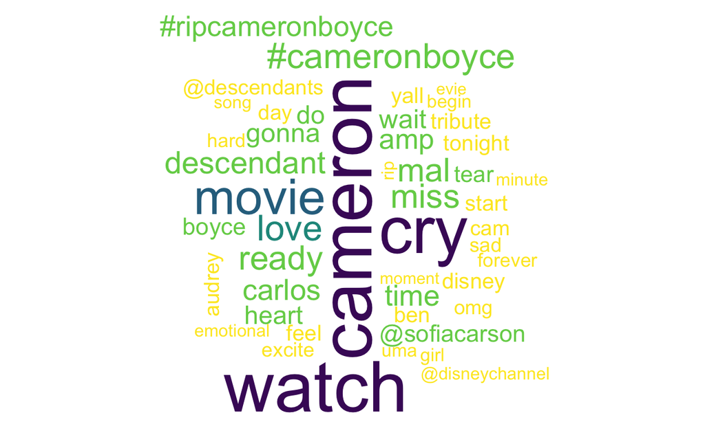

```r
# find tweets with loudly_crying_face
loudly_crying_face<-mon_thought[grep(count_emoji[1,1]$emoji,mon_thought$text),]%>%
  select(text)

# tokenization and remove stop words, url and punctuations
loudly_crying_face<-loudly_crying_face%>%
  unnest_tokens(output = 'word',
                input = 'text',
                token = 'tweets',
                to_lower = T,
                strip_punct=T,
                strip_url=T)%>%
  anti_join(stop_words)

# remove emojis
loudly_crying_face<-loudly_crying_face[!grepl('\\p{So}|\\p{C}', loudly_crying_face$word, perl = TRUE),]

#remove hashtag (#descendants3)
loudly_crying_face<-loudly_crying_face%>%
  filter(word!='#descendants3')

#lemmatization
loudly_crying_face$word<-lemmatize_words(loudly_crying_face$word)

# count
loudly_crying_face<-loudly_crying_face%>%
  group_by(word)%>%
  count(word)%>%
  arrange(desc(n))%>%
  filter(word!='im' & word!='3'& word!='2')

#wordcloud
pal <- c("#FDE725FF", "#73D055FF", "#1F968BFF","#2D708EFF", "#481567FF")
set.seed(123)
loudly_crying_face[1:50,]%>%
  with(wordcloud(word, n, max.words = 50,random.color = F,random.order = F,colors = pal))
```

### wordcloud for ❤

[output not shown]

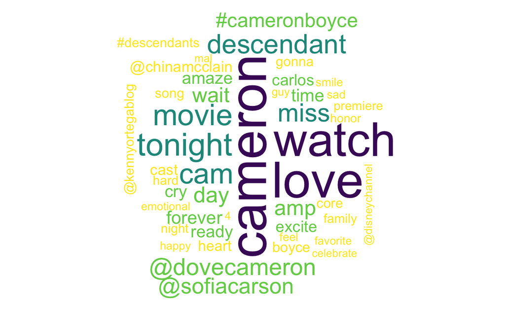

```r
# find tweets with heart
heart<-mon_thought[grep(count_emoji[2,1]$emoji,mon_thought$text),]%>%
  select(text)

# tokenization and remove stop words, url and punctuations
heart<-heart%>%
  unnest_tokens(output = 'word',
                input = 'text',
                token = 'tweets',
                to_lower = T,
                strip_punct=T,
                strip_url=T)%>%
  anti_join(stop_words)

# remove emojis
heart<-heart[!grepl('\\p{So}|\\p{C}', heart$word, perl = TRUE),]

#remove hashtag (#descendants3)
heart<-heart%>%
  filter(word!='#descendants3')

#lemmatization
heart$word<-lemmatize_words(heart$word)

# count
heart<-heart%>%
  group_by(word)%>%
  count(word)%>%
  arrange(desc(n))%>%
  filter(word!='im' & word!='3'& word!='2')

#wordcloud
pal <- c("#FDE725FF", "#73D055FF", "#1F968BFF","#2D708EFF", "#481567FF")
set.seed(123)
heart[1:50,]%>%
  with(wordcloud(word, n, max.words = 50,random.color = F,random.order = F,colors = pal))
```

‘Cameron’ and ‘Boyce’ appeared in a large pencatage of tweets containing 😭 and ❤. In addirion, ‘#ripcameronboyce’, ‘miss’ and ‘tear’ appeared many times as well. The reason for this is Cameron Boyce just passed away on July 6, 2019 at the age of 20 due to a complication of epilepsy. Thus, when descendants 3 comes out, many descendant series fans who are in great grief expressed their nostalgia to Cameron Boyce on twitter.

### wordcloud for 😂

[output not shown]

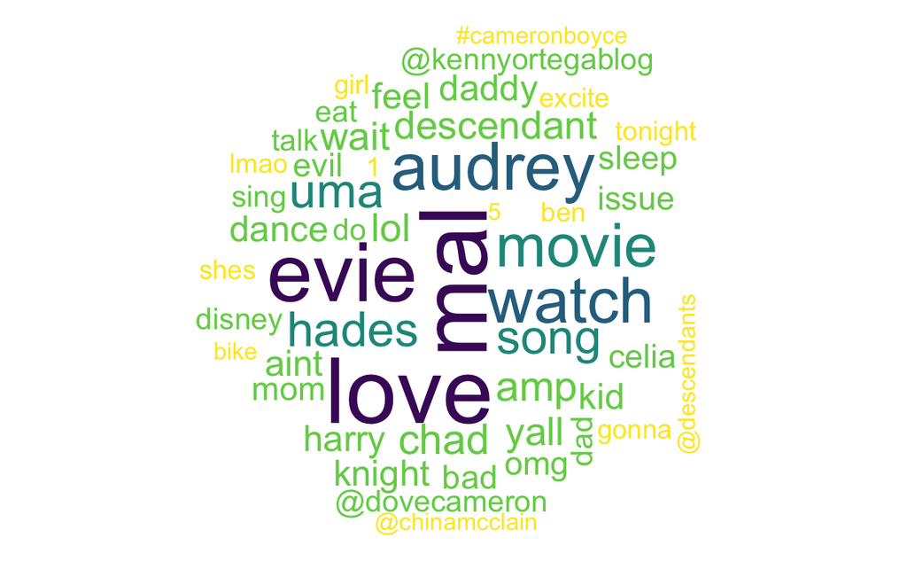

```r
# find tweets with face_with_tears_of_joy
face_with_tears_of_joy<-mon_thought[grep(count_emoji[3,1]$emoji,mon_thought$text),]%>%
  select(text)

# tokenization and remove stop words, url and punctuations
face_with_tears_of_joy<-face_with_tears_of_joy%>%
  unnest_tokens(output = 'word',
                input = 'text',
                token = 'tweets',
                to_lower = T,
                strip_punct=T,
                strip_url=T)%>%
  anti_join(stop_words)

# remove emojis
face_with_tears_of_joy<-face_with_tears_of_joy[!grepl('\\p{So}|\\p{C}', face_with_tears_of_joy$word, perl = TRUE),]

#remove hashtag (#descendants3)
face_with_tears_of_joy<-face_with_tears_of_joy%>%
  filter(word!='#descendants3')

#lemmatization
face_with_tears_of_joy$word<-lemmatize_words(face_with_tears_of_joy$word)

# count
face_with_tears_of_joy<-face_with_tears_of_joy%>%
  group_by(word)%>%
  count(word)%>%
  arrange(desc(n))%>%
  filter(word!='im' & word!='3'& word!='2')

#wordcloud
pal <- c("#FDE725FF", "#73D055FF", "#1F968BFF","#2D708EFF", "#481567FF")
set.seed(123)
face_with_tears_of_joy[1:50,]%>%
  with(wordcloud(word, n, max.words = 50,random.color = F,random.order = F,colors = pal))
```

The most frequent words in this wordcloud are essentially names of actors, like ‘mal’, ‘evie’ and ‘audrey’. Compared to mournful fans aforementioned, fans using 😂 apparently focused more on Descendants 3 itself. Tweets they posted indicates that they really enjoyed the TV film.

# Conclusion

In general, according to the most frequent emojis and their assiciated words, most viewers gave a postive feedback on Descendants 3 (lamenting for Cameron Boyce is a kind of positive feedback to some extent).